# Lesson 2A: Vector

DS 01-101: In-Depth Introduction to Data Science (Spring 2026)

Author

Affiliation

Hung Tong

Rowan University

## Readings

From **R Coding Basics: An Introduction to the Basics of Coding in R** by Dr. Gaston Sanchez:

- [First Contact with Vectors](https://www.gastonsanchez.com/R-coding-basics/1-01-vectors-intro.html)
- [Properties of Vectors](https://www.gastonsanchez.com/R-coding-basics/1-02-vectors-properties.html)
- [Creating Vectors](https://www.gastonsanchez.com/R-coding-basics/1-03-vectors-creation.html)
- [More about Vectors](https://www.gastonsanchez.com/R-coding-basics/1-04-vectors-concepts.html)

## Topics

- Vectors
- Atomic types
- Special values
- Creating vectors with `c()`, `:`, `seq()` , and `rep()`
- Useful functions for numeric vectors
- Built-in vectors

## Basic data structures

- Basic data structures in R include vector, factor, matrix, array, data frame, and list.

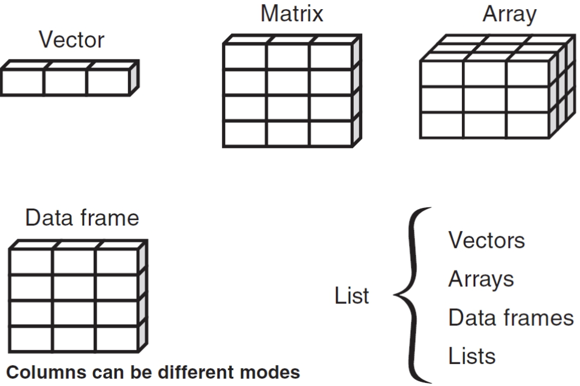

- These structures are characterized by their dimension and whether they require all elements to be of the same atomic type.

| Structure | Dimension | Same Atomic Type |
| --- | --- | --- |
| Vector | 1 | Yes |
| Factor | 1 | Yes |
| Matrix | 2 | Yes |
| Data Frame | 2 | No |
| Array | $\ge$ 2 | Yes |
| List | 1 | No |

## Vector

- A **vector** is a sequence of elements that are of the same **atomic** **type**.
- In R, the index of the first element is always **1**.

```r
#  1   2   3   4   5   6   7
c(70, 66, 82, 85, 78, 90, 73)
```

- A single value is treated as a vector of one element

```r
70    # same as c(70)
```

## Atomic types

- An **atomic type** refers to the six fundamental types in R: `logical`, `integer`, `double`, `character`, `raw`, and `complex`.
- Note that `integer` and `double` are also known as `numeric`.

```r
# logical vector
c(TRUE, FALSE, FALSE, TRUE, TRUE)
c(T, F, F, T, T)

# integer vector (numeric)
c(1L, 3L, 2L, 4L, 2L)

# double vector (numeric)
c(6.3, 8.2, 3.1, 4.4, 7.6)

# character vector
c("apple", "orange", "apple", "apple", "orange")
c('dog', 'cat', 'dog', 'dog', 'cat')

# raw and complex exist but not very popular
```

- The functions `typeof()` and `storage.mode()` tells us the atomic type of a vector.
- The function `mode()` works similarly, except that it returns `numeric` for both `integer` and `double`

```r
typeof(2.3)
```

```
#> [1] "double"
```

```r
storage.mode(2.3)
```

```
#> [1] "double"
```

```r
mode(2.3)
```

```
#> [1] "numeric"
```

- There are also dedicated checking function for each atomic type.

```r
is.logical()

is.integer()    # integer but not double
is.double()     # double but not integer
is.numeric()    # either integer or double

is.character()
```

**Hands-On**

Try the following R code to see what it returns.

```r
enrollment <- c(10, 30, 15, 20)

typeof(enrollment)

storage.mode(enrollment)

mode(enrollment)

is.integer(enrollment)

is.double(enrollment)

is.numeric(enrollment)
```

**Answer:**

```r
### R code here
```

## Special values

- `NULL` indicates an undefined object
- `NA` indicates missing or “not available” value
- `NaN` indicates an object that is “not a number”
- `Inf` indicates positive infinite
- `-Inf` indicates negative infinite

**Hands-On**

Try the following R code to see what it returns.

```r
sqrt(-7)

log(-5)

0 / 0

100 / 0

-100 / 0

log(0)
```

**Answer:**

```r
### R code here
```

## Creating vectors

- As shown previously, a vector can be manually created using the combine `c()` function.

```r
# logical vector
c(TRUE, FALSE, FALSE, TRUE, TRUE)
c(T, F, F, T, T)

# integer vector (numeric)
c(1L, 3L, 2L, 4L, 2L)

# double vector (numeric)
c(6.3, 8.2, 3.1, 4.4, 7.6)

# character vector
c("apple", "orange", "apple", "apple", "orange")
c('dog', 'cat', 'dog', 'dog', 'cat')
```

- Elements in a vector can have names!
- We can give names directly in `c()`

```r
c(exam1 = 90, exam2 = 85, final = 92)
```

[output not shown]

- We can also create the vector and assign names later

```r
scores <- c(90, 85, 92)
names(scores) <- c('exam1', 'exam2', 'exam3')
scores
```

```
#> exam1 exam2 exam3
#>    90    85    92
```

**Hands-On**

- Use `c()` to create a short vector for each of the four atomic types: `integer`, `double`, `logical`, and `character`.
- Assign each vector to a variable with a descriptive name.
- Choose one of your vectors and assign names to its elements.

**Answer:**

```r
### R code here
```

## Creating numeric vectors

### The colon operator

- The colon operator `:` generate a numeric sequence of one-unit steps by

```r
### start:end (end is like an upper/lower bound)

-2:5       # start with -2, increase by 1

5:-2       # start with 5, decrease by 1

3.7:9.2    # start with 3.7, increase by 1
```

**Hands-On**

- Using the colon operator `:` to quickly create the following vectors

```r
c(3, 4, 5, 6, 7, 8, 9, 10, 11, 12)

c(17, 16, 15, 14, 13, 12, 11, 10, 9)
```

**Answer:**

```r
### R code here
```

### The `seq()` function

- The `seq()` function generates a numeric sequence of more general steps.

```r
seq(from = -2, to = 5, by = 2)            # step size of 2

seq(from = -2, to = 5, by = 0.75)         # step size of 0.75

seq(from = -2, to = 5, length.out = 6)    # steps are automatically adjusted
```

**Hands-On**

Use the `seq()` function to create the vector that

- Starts at `5` and ends at `-3`, increasing or decreasing by `1`
- Starts at `-1` and ends at `7`, with a step size of `1.5`.
- Starts at `0` and ends at `10`, containing `5` equally spaced values.
- Starts at `-4` and ends at `4`, including only every other number.

**Answer:**

```r
### R code here
```

### The `req()` function

- The `rep()` function creates vectors with repeated elements.

```r
rep(-1, times = 5)                      # repeat -1 five times

rep(c(-1, 0, 2), times = 4)             # repeat c(-1, 0, 2) four times

rep(c(-1, 0, 3), times = c(2, 3, 4))    # repeat -1 two times, 0 three times, 3 four times

rep(c(-1, 0, 3), each = 5)              # repeat -1 five times, 0 five times, 3 five times
```

**Hands-On**

Use the `rep()` function to create the vector in which

- Each value in the vector `c(1, 3, 6)` is repeated exactly 4 times
- The value `4` is repeated `6` times
- The vector `c(2, −1, 1)` is repeated `3` times
- The values in `c(5, 0, −2)` are repeated so that `5` appears once, `0` appears three times, and `-2` appears four times.

**Answer:**

```r
### R code here
```

## Summary functions for numeric vectors

Given a vector,

- `length()` returns its length
- `min()` returns its minimum value
- `max()` returns its maximum value
- `which.min()` returns the index of its minimum value
- `which.max()` returns the index of its maximum value
- `sum()` returns the sum of its elements
- `prod()` returns the product of its elements

```r
#       1   2   3   4   5   6   7
v <- c(70, 66, 82, 85, 78, 90, 73)

length(v)

min(v)

which.min(v)

max(v)

which.max(v)

sum(v)

prod(v)
```

**Hands-On**

Consider a vector containing calorie content of light beer brands. Write R code to answer the following questions:

- How many light beer brands are included?
- What is the lowest calorie content among the light beers?
- What is the highest calorie content among the light beers?
- At which position does the highest calorie value occur?
- What is the total calorie content across all light beer brands?

```r
# Calories per 100ml of light beer
beer_cals <- c(29, 28, 33, 31, 30, 33, 30, 28, 27, 41, 39, 31, 29,
               23, 32, 31, 32, 19, 40, 22, 34, 31, 42, 35, 29, 43)
```

**Answer:**

```r
### R code here
```

**Hands-On**

Try the following R code to see what it returns.

```r
#       1   2   3   4   5   6   7
v <- c(70, 66, 82, 85, NA, 90, 73)

length(v)

min(v)

which.min(v)

max(v)

which.max(v)

sum(v)

prod(v)
```

## Built-in vectors

- R includes several built-in vectors for alphabets, $\pi$, months, and US states.

**Hands-On**

Try the following R code and see what it returns. Feel free to get the help documentation.

```r
LETTERS
letters

month.abb
month.name

pi

state.abb
state.name
state.area
```